# Cofidence Intervals - Week 3

Previously confidence intervals were discussed using CLT. The intervals took the form:

$$Est \pm Z \times SE_{Est}$$

This chapter concerns methods for small samples, notably Gosset’s t distribution and t confidence intervals.

These intervals are of the forms:

$$Est \pm t \times SE_{Est}$$
$Z$ quantile is replaced with a $t$ quantile.

## Gosset’s $t$ distribution

- Invented by William Gosset (under the pseudonym “Student”) in 1908
- Has thicker tails than the normal
- Is indexed by a degrees of freedom; gets more like a standard normal as df gets larger
- It assumes that the underlying data are iid

Gaussian with the result that
$$\frac{\bar X - \mu}{S/\sqrt{n}}$$
follows Gosset’s $t$ distribution with $n-1$ degrees of freedom

- (If we replaced $S$ by $\sigma$ the statistic would be exactly standard normal)
- Interval is $\bar X \pm t_{n-1} S/\sqrt{n}$ where $t_{n-1}$ is the relevant quantile

As $n$ increases the distinction between t distribution and the standard normal becomes irrelevant. However, for small sample sizes the difference can be quite large. So using standard nomals for small sample sizes could give CI that are too narrow.

http://blog.minitab.com/blog/statistics-and-quality-data-analysis/what-are-degrees-of-freedom-in-statistics

https://www.statsdirect.com/help/basics/degrees_of_freedom.htm

## Code for manipulate

How the t distribution overlays over the normal distribution for different degrees of freedom:

For 20 degrees of freedom, they are similar.

As the degrees of freedom are draw down, the t distribution gets to the point in which it has heavier tail

```r
k <- 1000
xvals <- seq(-5, 5, length = k)
myplot <- function(df){
  d <- data.frame(y = c(dnorm(xvals), dt(xvals, df)),
                  x = xvals,
                  dist = factor(rep(c("Normal", "T"), c(k,k))))
  g <- ggplot(d, aes(x = x, y = y))
  g <- g + geom_line(size = 2, aes(colour = dist))
  g
}
manipulate(myplot(mu), mu = slider(1, 20, step = 1))
```

## Easier to see

Quantiles of the t distribution by the quantiles of the normal distributions, starting at the 50th percentile.

At zero and 50th percentile, since both distributions are symmetric about zero, zero is the 50th percentile.

The vertical and horizontal lines are reference lines at the 97th quantile. It’s around 1.96 for the standard normal distribution and can be larger for the t distribution. For example, at 2 df, t quantile is over 4.

At 20 df t quantiles are much closer to normal quantiles. Where the vertical and horizontal lines meet, the distance between the blue and black lines is the distinction between the two intervals.

The t quantile will always be above the blue reference line, which is effectively saying that the t constricted confidence interval will always be wider than the normal interval. Uncertainty would cause the wider interval.

```r
pvals <- seq(.5, .99, by = .01)
myplot2 <- function(df){
  d <- data.frame(n= qnorm(pvals),t=qt(pvals, df),
                  p = pvals)
  g <- ggplot(d, aes(x= n, y = t))
  g <- g + geom_abline(size = 2, col = "lightblue")
  g <- g + geom_line(size = 2, col = "black")
  g <- g + geom_vline(xintercept = qnorm(0.975))
  g <- g + geom_hline(yintercept = qt(0.975, df))
  g
}
manipulate(myplot2(df), df = slider(1, 20, step = 1))
```

## Note’s about the $t$ interval

- The $t$ interval technically assumes that the data are iid normal, though it is robust to this assumption
- It works well whenever the distribution of the data is roughly symmetric and mound shaped
- Paired observations are often analyzed using the $t$ interval by taking differences
- For large degrees of freedom, $t$ quantiles become the same as standard normal quantiles; therefore this interval converges to the same interval as the CLT yielded
- For skewed distributions, the spirit of the $t$ interval assumptions are violated
  - Also, for skewed distributions, it doesn’t make a lot of sense to center the interval at the mean
  - In this case, consider taking logs or using a different summary like the median
- For highly discrete data, like binary, other intervals are available

## Sleep data

In R typing `data(sleep)` brings up the sleep data originally analyzed in Gosset’s Biometrika paper, which shows the increase in hours for 10 patients on two soporific drugs. R treats the data as two groups rather than paired.

## The data

```r
data(sleep)
head(sleep)
```

```
##   extra group ID
## 1   0.7     1  1
## 2  -1.6     1  2
## 3  -0.2     1  3
## 4  -1.2     1  4
## 5  -0.1     1  5
## 6   3.4     1  6
```

```r
# extra = extra hours slept
# group = group ID
# ID = subject ID
```

## Plotting the data

Each subject is connected with a line

These are repeated measurements on the same subject.

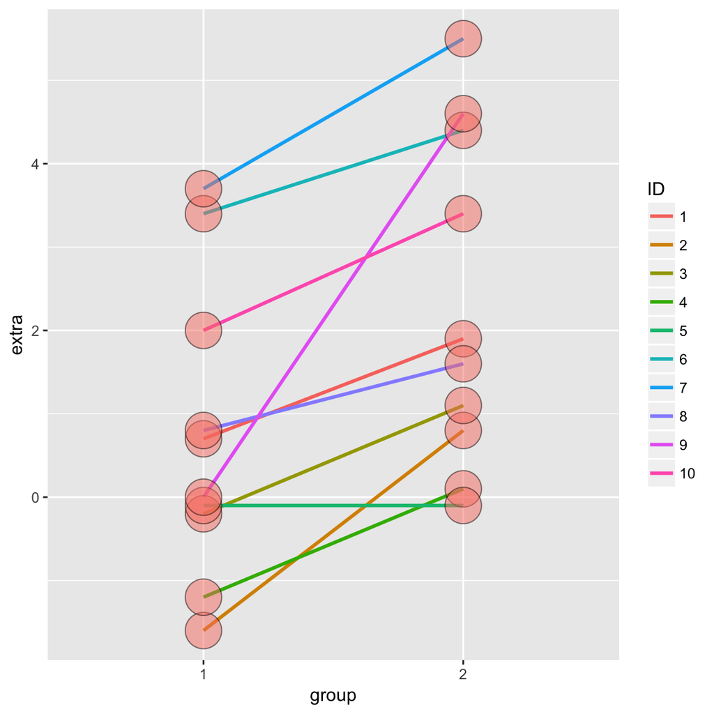

## Results

```r
g1 <- sleep$extra[1 : 10] # 1st 10 measurememnts (subjects 1 through 10)
g2 <- sleep$extra[11 : 20] # 2nd 10 measurements (subjects 1 through 10 on the second medication)
difference <- g2 - g1
mn <- mean(difference); s <- sd(difference); n <- 10
```

```r
# t confidence interval
mn + c(-1, 1) * qt(.975, n-1) * s / sqrt(n)

# or
t.test(difference)
# or
t.test(g2, g1, paired = TRUE)
# or
t.test(extra ~ I(relevel(group, 2)), paired = TRUE, data = sleep)
```

## The results

(After a little formatting)

```
##           [,1]     [,2]
## [1,] 0.7001142 2.459886
## [2,] 0.7001142 2.459886
## [3,] 0.7001142 2.459886
## [4,] 0.7001142 2.459886
```

## Independent group $t$ confidence intervals

- Suppose that we want to compare the mean blood pressure between two groups in a randomized trial; those who received the treatment to those who received a placebo
- We cannot use the paired t test because the groups are independent and may have different sample sizes
- We now present methods for comparing independent groups

## Confidence interval

- Therefore a $(1 - \alpha)\times 100\%$ confidence interval for $\mu_y - \mu_x$ is
  $$\bar Y - \bar X \pm t_{n_x + n_y - 2, 1 - \alpha/2}S_p\left(\frac{1}{n_x} + \frac{1}{n_y}\right)^{1/2}$$

Note that the df is $n_x + n_y - 2$

- The pooled variance estimator is
  $$S_p^2 = \{(n_x - 1) S_x^2 + (n_y - 1) S_y^2\}/(n_x + n_y - 2)$$
- Remember this interval is assuming a constant variance across the two groups
- If there is some doubt, assume a different variance per group, which we will discuss later

## Example

### Based on Rosner, Fundamentals of Biostatistics

(Really a very good reference book)

- Comparing SBP for 8 oral contraceptive users versus 21 controls
- $\bar X_{OC} = 132.86$ mmHg with $s_{OC} = 15.34$ mmHg
- $\bar X_{C} = 127.44$ mmHg with $s_{C} = 18.23$ mmHg
- Pooled variance estimate

```r
# it's sqrt because I want the standard deviation!
sp <- sqrt(((8-1) * 15.34^2 + (21-1) * 18.23^2) / (8 + 21 - 2)) # 17.52

# for the interval
# difference in the means +- 1 * t quatile with 27df[21 + 8 - 2] * sp * the rest
132.86 - 127.44 + c(-1, 1) * qt(.975, 27) * sp * (1 / 8 + 1 / 21)^.5
```

```
## [1] -9.521097 20.361097
```

```r
# in this case, the interval contains zero, so I cannot rulle out zero as the difference of the 2 population groups
```

## Mistakenly treating the sleep data as grouped

```r
x1 <- sleep$extra[1 : 10]
x2 <- sleep$extra[11 : 20]
n1 <- length(g1)
n2 <- length(g2)
sp <- sqrt( ((n1 - 1) * sd(x1)^2 + (n2-1) * sd(x2)^2) / (n1 + n2-2))
md <- mean(g2) - mean(g1) # mean difference
semd <- sp * sqrt(1 / n1 + 1/n2) # SE of the mean difference
rbind(
md + c(-1, 1) * qt(.975, n1 + n2 - 2) * semd,
t.test(g2, g1, paired = FALSE, var.equal = TRUE)$conf,
t.test(g2, g1, paired = TRUE)$conf
)
```

```
##            [,1]     [,2]
## [1,] -0.2038740 3.363874
## [2,] -0.2038740 3.363874
## [3,]  0.7001142 2.459886
```

## Grouped versus independent

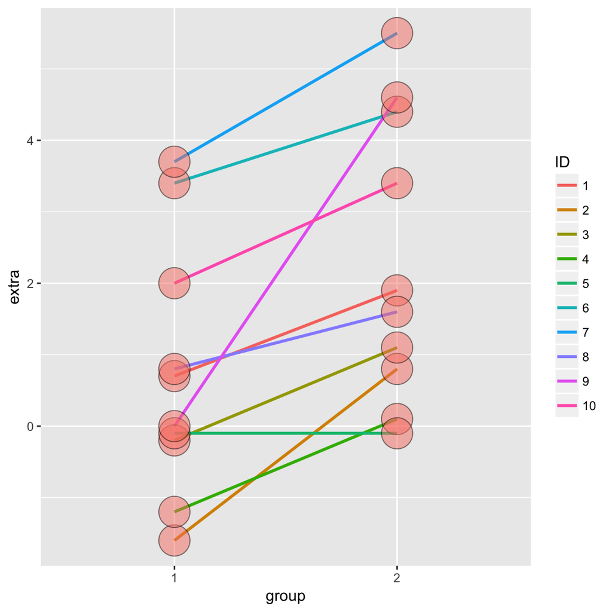

## `ChickWeight` data in R

```r
data(ChickWeight)
##define weight gain or loss
wideCW <- dcast(ChickWeight, Diet + Chick ~ Time, value.var = "weight")
names(wideCW)[-(1 : 2)] <- paste("time", names(wideCW)[-(1 : 2)], sep = "")
wideCW <- mutate(wideCW, gain = time21 - time0)
```

## Plotting the raw data

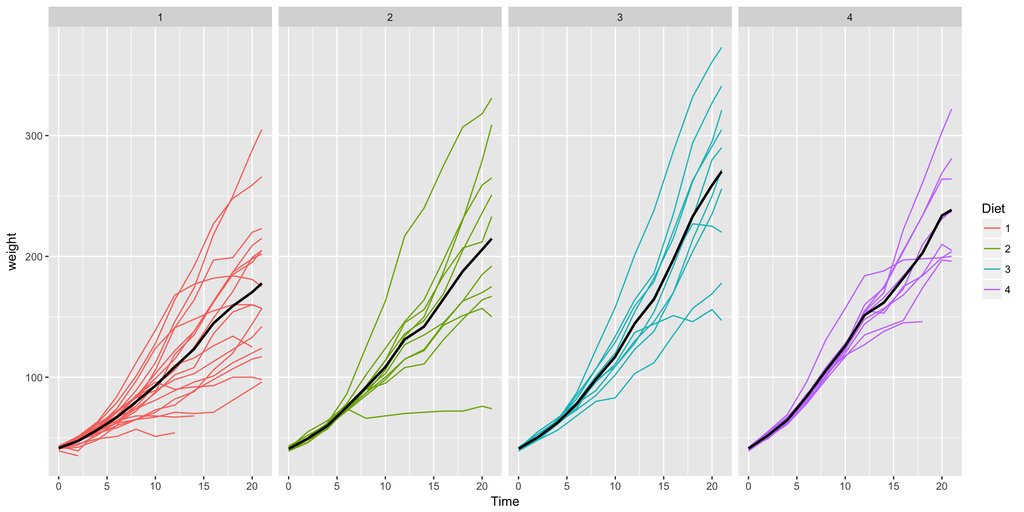

## Weight gain by diet

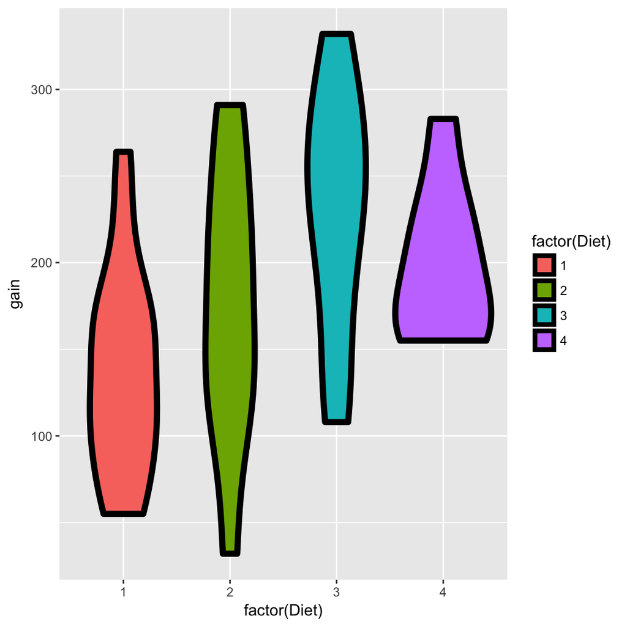

## Let’s do a t interval

```r
wideCW14 <- subset(wideCW, Diet %in% c(1, 4)) # ommiting diets 2 and 3
rbind(
t.test(gain ~ Diet, paired = FALSE, var.equal = TRUE, data = wideCW14)$conf, # comparing variance are equal against
t.test(gain ~ Diet, paired = FALSE, var.equal = FALSE, data = wideCW14)$conf #variances being unequal
)
```

```
##           [,1]      [,2]
## [1,] -108.1468 -14.81154
## [2,] -104.6590 -18.29932
```

```r
# for both cases the ontervals are below zero, suggesting less weight gain on diet 1 than on diet 4
```

## Unequal variances

- Under unequal variances
  $$\bar Y - \bar X \pm t_{df} \times \left(\frac{s_x^2}{n_x} + \frac{s_y^2}{n_y}\right)^{1/2}$$
  where $t_{df}$ is calculated with degrees of freedom
  $$df= \frac{\left(S_x^2 / n_x + S_y^2/n_y\right)^2}
  {\left(\frac{S_x^2}{n_x}\right)^2 / (n_x - 1) +
  \left(\frac{S_y^2}{n_y}\right)^2 / (n_y - 1)}$$
  will be approximately a 95% interval
- This works really well
  - So when in doubt, just assume unequal variances

## Example

- Comparing SBP for 8 oral contraceptive users versus 21 controls
- $\bar X_{OC} = 132.86$ mmHg with $s_{OC} = 15.34$ mmHg
- $\bar X_{C} = 127.44$ mmHg with $s_{C} = 18.23$ mmHg
- $df=15.04$, $t_{15.04, .975} = 2.13$
- Interval
  $$132.86 - 127.44 \pm 2.13 \left(\frac{15.34^2}{8} + \frac{18.23^2}{21} \right)^{1/2}
  = [-8.91, 19.75]$$
- In R, `t.test(..., var.equal = FALSE)`

## Comparing other kinds of data

- For binomial data, there’s lots of ways to compare two groups
  - Relative risk, risk difference, odds ratio.
  - Chi-squared tests, normal approximations, exact tests.
- For count data, there’s also Chi-squared tests and exact tests.
- We’ll leave the discussions for comparing groups of data for binary and count data until covering glms in the regression class.
- In addition, Mathematical Biostatistics Boot Camp 2 covers many special cases relevant to biostatistics.

## Exercises

1. For iid Gaussian data, the statistic $\frac{\bar X - \mu}{s / \sqrt{n}}$ must follow a:
- t distribution
- https://stats.stackexchange.com/questions/319754/why-a-t-statistic-needs-the-data-to-follow-a-normal-distribution
2. Paired differences T confidence intervals are useful when:
- Pairs of observations are linked, such as when there is subject level matching or in a study with baseline and follow up measurements on all participants.
3. The assumption that the variances are equal for the independent group T interval means that:
- The population variances are identical, but the sample variances may be different.
4. Load the data set mtcars in the datasets R package. Calculate a 95% confidence interval to the nearest MPG for the variable `mpg`.

```r
data(mtcars)
head(mtcars)
```

```
##                    mpg cyl disp  hp drat    wt  qsec vs am gear carb
## Mazda RX4         21.0   6  160 110 3.90 2.620 16.46  0  1    4    4
## Mazda RX4 Wag     21.0   6  160 110 3.90 2.875 17.02  0  1    4    4
## Datsun 710        22.8   4  108  93 3.85 2.320 18.61  1  1    4    1
## Hornet 4 Drive    21.4   6  258 110 3.08 3.215 19.44  1  0    3    1
## Hornet Sportabout 18.7   8  360 175 3.15 3.440 17.02  0  0    3    2
## Valiant           18.1   6  225 105 2.76 3.460 20.22  1  0    3    1
```

```r
attach(mtcars) # so I dont have to type the $ sign
t.test(mpg)
```

```
##
##  One Sample t-test
##
## data:  mpg
## t = 18.857, df = 31, p-value < 2.2e-16
## alternative hypothesis: true mean is not equal to 0
## 95 percent confidence interval:
##  17.91768 22.26357
## sample estimates:
## mean of x
##  20.09062
```

```r
t.test(mpg)$conf.int # only the t interval
```

```
## [1] 17.91768 22.26357
## attr(,"conf.level")
## [1] 0.95
```

5. Suppose that standard deviation of 9 paired differences is 1. What value would the average difference have to be so that the lower endpoint of a 95% students t confidence interval touches zero?
- paired differences: I have pair of measurements, and I subtract them
- the idea of the pair difference interval is:

$${\bar y} \pm t_{0.975} \times \frac{sdev}{\sqrt n}$$
* where ${\bar y}$ is the average difference * as I am interested in the lower end point, so forget about the + in the equantion # also it needs to be equalt to zero

$${\bar y} - t_{0.975} \times \frac{sdev}{\sqrt n} = 0$$

- Replacing values:

$${\bar y} \pm t_{0.975} \times \frac{1}{\sqrt 9} = 0$$

$${\bar y} = \pm t_{0.975} \times \frac{1}{3}$$
* now it’s necessary to find out whats the 97.5th quantile is

```r
n <- 9
sdev <- 1
ybar <- qt(0.975, df = n - 1) / 3
ybar
```

```
## [1] 0.768668
```

6. An independent group Student’s T interval is used instead of a paired T interval when:
- The observations between the groups are naturally assumed to be statistically independent.
7. Consider the `mtcars` dataset. Construct a 95% T interval for MPG comparing 4 to 6 cylinder cars (subtracting in the order of 4 - 6) assume a constant variance.

```r
data(mtcars)
head(mtcars)
```

```
##                    mpg cyl disp  hp drat    wt  qsec vs am gear carb
## Mazda RX4         21.0   6  160 110 3.90 2.620 16.46  0  1    4    4
## Mazda RX4 Wag     21.0   6  160 110 3.90 2.875 17.02  0  1    4    4
## Datsun 710        22.8   4  108  93 3.85 2.320 18.61  1  1    4    1
## Hornet 4 Drive    21.4   6  258 110 3.08 3.215 19.44  1  0    3    1
## Hornet Sportabout 18.7   8  360 175 3.15 3.440 17.02  0  0    3    2
## Valiant           18.1   6  225 105 2.76 3.460 20.22  1  0    3    1
```

```r
c4 <- mtcars$mpg[mtcars$cyl== 4]
c6 <- mtcars$mpg[mtcars$cyl== 6]

t.test(c4, c6, var.equal = TRUE)
```

```
##
##  Two Sample t-test
##
## data:  c4 and c6
## t = 3.8952, df = 16, p-value = 0.001287
## alternative hypothesis: true difference in means is not equal to 0
## 95 percent confidence interval:
##   3.154286 10.687272
## sample estimates:
## mean of x mean of y
##  26.66364  19.74286
```

8. If someone put a gun to your head and said “Your confidence interval must contain what it’s estimating or I’ll pull the trigger”, what would be the smart thing to do?
- Make your interval as wide as possible.
- Make your interval as small as possible.
- Call the authorities. Watch the video solution and see the text.
9. Refer back to comparing MPG for 4 versus 6 cylinders (question 7). What do you conclude?
- The interval is above zero, suggesting 6 is better than 4 in the terms of MPG.
- The interval is above zero, suggesting 4 is better than 6 in the terms of MPG.
- The interval does not tell you anything about the hypothesis test; you have to do the test.
- The interval contains 0 suggesting no difference. Watch a video solution and see the text.
10. Suppose that 18 obese subjects were randomized, 9 each, to a new diet pill and a placebo. Subjects’ body mass indices (BMIs) were measured at a baseline and again after having received the treatment or placebo for four weeks. The average difference from follow-up to the baseline (followup - baseline) was 3 kg/m2 for the treated group and 1 kg/m2 for the placebo group. The corresponding standard deviations of the differences was 1.5 kg/m2 for the treatment group and 1.8 kg/m2 for the placebo group. The study aims to answer whether the change in BMI over the four week period appear to differ between the treated and placebo groups. What is the pooled variance estimate?